# Risk Factor Analysis

## Outcome Variable

**Outcome Variable:** ever_stunted

## Predictor Variables

**Intervention Variable:** parity

**Adjustment Set:**

- arm
- W_mage
- meducyrs
- feducyrs
- hhwealth_quart
- W_mhtcm
- vagbrth
- W_nrooms
- impsan
- delta_W_mage
- delta_meducyrs
- delta_feducyrs
- delta_hhwealth_quart
- delta_W_mhtcm
- delta_vagbrth
- delta_W_nrooms
- delta_impsan

## Stratifying Variables

The analysis was stratified on these variable(s):

- agecat
- studyid
- country

## Data Summary

| agecat | studyid | country | parity | ever_stunted | n_cell | n |
| --- | --- | --- | --- | --- | --- | --- |
| 0-6 months | ki1000304b-SAS-CompFeed | INDIA | 1 | 0 | 289 | 1530 |
| 0-6 months | ki1000304b-SAS-CompFeed | INDIA | 1 | 1 | 162 | 1530 |
| 0-6 months | ki1000304b-SAS-CompFeed | INDIA | 2 | 0 | 266 | 1530 |
| 0-6 months | ki1000304b-SAS-CompFeed | INDIA | 2 | 1 | 93 | 1530 |
| 0-6 months | ki1000304b-SAS-CompFeed | INDIA | 3+ | 0 | 534 | 1530 |
| 0-6 months | ki1000304b-SAS-CompFeed | INDIA | 3+ | 1 | 186 | 1530 |
| 0-6 months | ki1000304b-SAS-FoodSuppl | INDIA | 1 | 0 | 46 | 396 |
| 0-6 months | ki1000304b-SAS-FoodSuppl | INDIA | 1 | 1 | 31 | 396 |
| 0-6 months | ki1000304b-SAS-FoodSuppl | INDIA | 2 | 0 | 58 | 396 |
| 0-6 months | ki1000304b-SAS-FoodSuppl | INDIA | 2 | 1 | 33 | 396 |
| 0-6 months | ki1000304b-SAS-FoodSuppl | INDIA | 3+ | 0 | 139 | 396 |
| 0-6 months | ki1000304b-SAS-FoodSuppl | INDIA | 3+ | 1 | 89 | 396 |
| 0-6 months | ki1017093b-PROVIDE | BANGLADESH | 1 | 0 | 245 | 700 |
| 0-6 months | ki1017093b-PROVIDE | BANGLADESH | 1 | 1 | 26 | 700 |
| 0-6 months | ki1017093b-PROVIDE | BANGLADESH | 2 | 0 | 218 | 700 |
| 0-6 months | ki1017093b-PROVIDE | BANGLADESH | 2 | 1 | 26 | 700 |
| 0-6 months | ki1017093b-PROVIDE | BANGLADESH | 3+ | 0 | 171 | 700 |
| 0-6 months | ki1017093b-PROVIDE | BANGLADESH | 3+ | 1 | 14 | 700 |
| 0-6 months | ki1066203-TanzaniaChild2 | TANZANIA, UNITED REPUBLIC OF | 1 | 0 | 775 | 2363 |
| 0-6 months | ki1066203-TanzaniaChild2 | TANZANIA, UNITED REPUBLIC OF | 1 | 1 | 67 | 2363 |
| 0-6 months | ki1066203-TanzaniaChild2 | TANZANIA, UNITED REPUBLIC OF | 2 | 0 | 731 | 2363 |
| 0-6 months | ki1066203-TanzaniaChild2 | TANZANIA, UNITED REPUBLIC OF | 2 | 1 | 43 | 2363 |
| 0-6 months | ki1066203-TanzaniaChild2 | TANZANIA, UNITED REPUBLIC OF | 3+ | 0 | 698 | 2363 |
| 0-6 months | ki1066203-TanzaniaChild2 | TANZANIA, UNITED REPUBLIC OF | 3+ | 1 | 49 | 2363 |
| 0-6 months | ki1101329-Keneba | GAMBIA | 1 | 0 | 198 | 1853 |
| 0-6 months | ki1101329-Keneba | GAMBIA | 1 | 1 | 37 | 1853 |
| 0-6 months | ki1101329-Keneba | GAMBIA | 2 | 0 | 187 | 1853 |
| 0-6 months | ki1101329-Keneba | GAMBIA | 2 | 1 | 18 | 1853 |
| 0-6 months | ki1101329-Keneba | GAMBIA | 3+ | 0 | 1320 | 1853 |
| 0-6 months | ki1101329-Keneba | GAMBIA | 3+ | 1 | 93 | 1853 |

[output cut: 165 more lines]

The following strata were considered:

- agecat: 0-24 months, studyid: ki1000304b-SAS-CompFeed, country: INDIA
- agecat: 0-24 months, studyid: ki1000304b-SAS-FoodSuppl, country: INDIA
- agecat: 0-24 months, studyid: ki1017093b-PROVIDE, country: BANGLADESH
- agecat: 0-24 months, studyid: ki1066203-TanzaniaChild2, country: TANZANIA, UNITED REPUBLIC OF
- agecat: 0-24 months, studyid: ki1101329-Keneba, country: GAMBIA
- agecat: 0-24 months, studyid: ki1113344-GMS-Nepal, country: NEPAL
- agecat: 0-24 months, studyid: ki1126311-ZVITAMBO, country: ZIMBABWE
- agecat: 0-24 months, studyid: ki1135781-COHORTS, country: GUATEMALA
- agecat: 0-24 months, studyid: ki1135781-COHORTS, country: INDIA
- agecat: 0-24 months, studyid: ki1135781-COHORTS, country: PHILIPPINES
- agecat: 0-24 months, studyid: kiGH5241-JiVitA-3, country: BANGLADESH
- agecat: 0-6 months, studyid: ki1000304b-SAS-CompFeed, country: INDIA
- agecat: 0-6 months, studyid: ki1000304b-SAS-FoodSuppl, country: INDIA
- agecat: 0-6 months, studyid: ki1017093b-PROVIDE, country: BANGLADESH
- agecat: 0-6 months, studyid: ki1066203-TanzaniaChild2, country: TANZANIA, UNITED REPUBLIC OF
- agecat: 0-6 months, studyid: ki1101329-Keneba, country: GAMBIA
- agecat: 0-6 months, studyid: ki1113344-GMS-Nepal, country: NEPAL
- agecat: 0-6 months, studyid: ki1126311-ZVITAMBO, country: ZIMBABWE
- agecat: 0-6 months, studyid: ki1135781-COHORTS, country: GUATEMALA
- agecat: 0-6 months, studyid: ki1135781-COHORTS, country: INDIA
- agecat: 0-6 months, studyid: ki1135781-COHORTS, country: PHILIPPINES
- agecat: 0-6 months, studyid: kiGH5241-JiVitA-3, country: BANGLADESH
- agecat: 6-24 months, studyid: ki1000304b-SAS-CompFeed, country: INDIA
- agecat: 6-24 months, studyid: ki1000304b-SAS-FoodSuppl, country: INDIA
- agecat: 6-24 months, studyid: ki1017093b-PROVIDE, country: BANGLADESH
- agecat: 6-24 months, studyid: ki1066203-TanzaniaChild2, country: TANZANIA, UNITED REPUBLIC OF
- agecat: 6-24 months, studyid: ki1101329-Keneba, country: GAMBIA
- agecat: 6-24 months, studyid: ki1113344-GMS-Nepal, country: NEPAL
- agecat: 6-24 months, studyid: ki1126311-ZVITAMBO, country: ZIMBABWE
- agecat: 6-24 months, studyid: ki1135781-COHORTS, country: GUATEMALA
- agecat: 6-24 months, studyid: ki1135781-COHORTS, country: INDIA
- agecat: 6-24 months, studyid: ki1135781-COHORTS, country: PHILIPPINES
- agecat: 6-24 months, studyid: kiGH5241-JiVitA-3, country: BANGLADESH

## Methods Detail

We’re interested in the causal parameters $E[Y_a]$ for all values of $a \in \mathcal{A}$. These parameters represent the mean outcome if, possibly contrary to fact, we intervened to set all units to have $A=a$. Under the randomization and positivity assumptions, these are identified by the statistical parameters $\psi_a=E_W[E_{Y|A,W}(Y|A=a,W)]$. In addition, we’re interested in the mean of $Y$, $E[Y]$ under no intervention (the observed mean). We will estimate these parameters by using SuperLearner to fit the relevant likelihood factors – $E_{Y|A,W}(Y|A=a,W)$ and $p(A=a|W)$, and then updating our likelihood fit using a joint TMLE.

For unadjusted analyses ($W=\{\}$), initial likelihoods were estimated using Lrnr_glm to estimate the simple $E(Y|A)$ and Lrnr_mean to estimate $p(A)$. For adjusted analyses, a small library containing Lrnr_glmnet, Lrnr_xgboost, and Lrnr_mean was used.

Having estimated these parameters, we will then use the delta method to estimate relative risks and attributable risks relative to a prespecified baseline level of $A$.

```
##       ever_stunted
## parity    0
##     1   622
##     2   934
##     3+ 1928
```

# Results Detail

## Results Plots

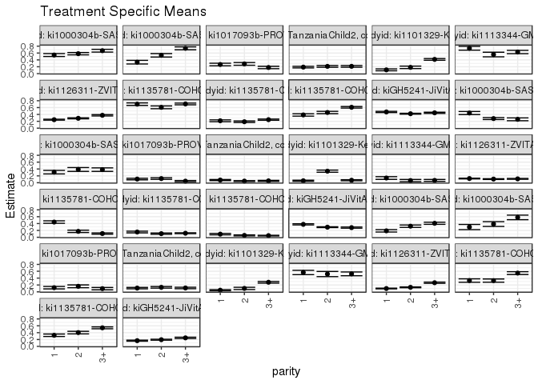

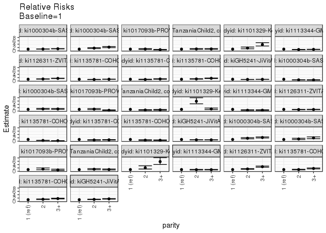

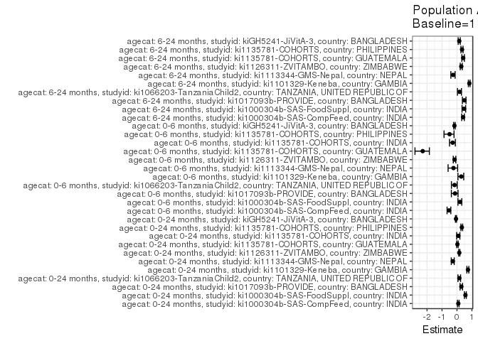

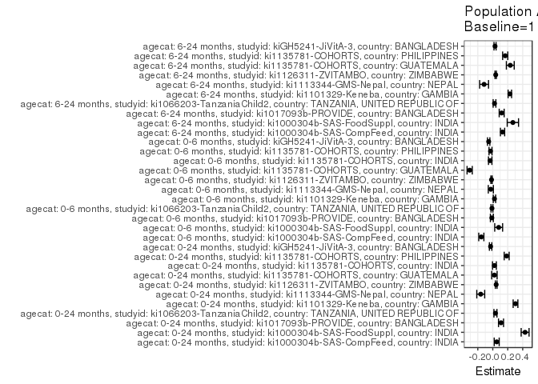

## Results Table

### Parameter: TSM

| agecat | studyid | country | intervention_level | baseline_level | estimate | ci_lower | ci_upper |
| --- | --- | --- | --- | --- | --- | --- | --- |
| 0-24 months | ki1000304b-SAS-CompFeed | INDIA | 1 | NA | 0.5418314 | 0.4994195 | 0.5842433 |
| 0-24 months | ki1000304b-SAS-CompFeed | INDIA | 2 | NA | 0.5809313 | 0.5472545 | 0.6146082 |
| 0-24 months | ki1000304b-SAS-CompFeed | INDIA | 3+ | NA | 0.6678254 | 0.6276413 | 0.7080095 |
| 0-24 months | ki1000304b-SAS-FoodSuppl | INDIA | 1 | NA | 0.3337772 | 0.2811598 | 0.3863945 |
| 0-24 months | ki1000304b-SAS-FoodSuppl | INDIA | 2 | NA | 0.5331658 | 0.4828454 | 0.5834862 |
| 0-24 months | ki1000304b-SAS-FoodSuppl | INDIA | 3+ | NA | 0.7363693 | 0.6935052 | 0.7792334 |
| 0-24 months | ki1017093b-PROVIDE | BANGLADESH | 1 | NA | 0.2654055 | 0.2283791 | 0.3024318 |
| 0-24 months | ki1017093b-PROVIDE | BANGLADESH | 2 | NA | 0.2829754 | 0.2431534 | 0.3227973 |
| 0-24 months | ki1017093b-PROVIDE | BANGLADESH | 3+ | NA | 0.1789556 | 0.1445549 | 0.2133563 |
| 0-24 months | ki1066203-TanzaniaChild2 | TANZANIA, UNITED REPUBLIC OF | 1 | NA | 0.1895794 | 0.1663012 | 0.2128576 |
| 0-24 months | ki1066203-TanzaniaChild2 | TANZANIA, UNITED REPUBLIC OF | 2 | NA | 0.2110864 | 0.1852904 | 0.2368824 |
| 0-24 months | ki1066203-TanzaniaChild2 | TANZANIA, UNITED REPUBLIC OF | 3+ | NA | 0.2124029 | 0.1869964 | 0.2378094 |
| 0-24 months | ki1101329-Keneba | GAMBIA | 1 | NA | 0.1097626 | 0.0819017 | 0.1376234 |
| 0-24 months | ki1101329-Keneba | GAMBIA | 2 | NA | 0.1829707 | 0.1476204 | 0.2183210 |
| 0-24 months | ki1101329-Keneba | GAMBIA | 3+ | NA | 0.4148680 | 0.3898801 | 0.4398559 |
| 0-24 months | ki1113344-GMS-Nepal | NEPAL | 1 | NA | 0.7388129 | 0.6832442 | 0.7943816 |
| 0-24 months | ki1113344-GMS-Nepal | NEPAL | 2 | NA | 0.5567862 | 0.4896965 | 0.6238759 |
| 0-24 months | ki1113344-GMS-Nepal | NEPAL | 3+ | NA | 0.6291197 | 0.5812296 | 0.6770097 |
| 0-24 months | ki1126311-ZVITAMBO | ZIMBABWE | 1 | NA | 0.2469649 | 0.2339611 | 0.2599688 |
| 0-24 months | ki1126311-ZVITAMBO | ZIMBABWE | 2 | NA | 0.2873785 | 0.2724232 | 0.3023337 |
| 0-24 months | ki1126311-ZVITAMBO | ZIMBABWE | 3+ | NA | 0.3755282 | 0.3550844 | 0.3959721 |
| 0-24 months | ki1135781-COHORTS | GUATEMALA | 1 | NA | 0.6996789 | 0.6625917 | 0.7367662 |
| 0-24 months | ki1135781-COHORTS | GUATEMALA | 2 | NA | 0.6075511 | 0.5665949 | 0.6485072 |
| 0-24 months | ki1135781-COHORTS | GUATEMALA | 3+ | NA | 0.7061253 | 0.6801645 | 0.7320861 |
| 0-24 months | ki1135781-COHORTS | INDIA | 1 | NA | 0.2149273 | 0.1878731 | 0.2419815 |
| 0-24 months | ki1135781-COHORTS | INDIA | 2 | NA | 0.1875982 | 0.1651881 | 0.2100083 |
| 0-24 months | ki1135781-COHORTS | INDIA | 3+ | NA | 0.2479506 | 0.2313448 | 0.2645564 |
| 0-24 months | ki1135781-COHORTS | PHILIPPINES | 1 | NA | 0.3858909 | 0.3508294 | 0.4209525 |
| 0-24 months | ki1135781-COHORTS | PHILIPPINES | 2 | NA | 0.4569787 | 0.4229439 | 0.4910135 |
| 0-24 months | ki1135781-COHORTS | PHILIPPINES | 3+ | NA | 0.6084931 | 0.5858298 | 0.6311564 |

[output cut: 66 more lines]

### Parameter: E(Y)

| agecat | studyid | country | intervention_level | baseline_level | estimate | ci_lower | ci_upper |
| --- | --- | --- | --- | --- | --- | --- | --- |
| 0-24 months | ki1000304b-SAS-CompFeed | INDIA | NA | NA | 0.5942596 | 0.5539147 | 0.6346046 |
| 0-24 months | ki1000304b-SAS-FoodSuppl | INDIA | NA | NA | 0.7657431 | 0.7240285 | 0.8074577 |
| 0-24 months | ki1017093b-PROVIDE | BANGLADESH | NA | NA | 0.3757143 | 0.3398113 | 0.4116172 |
| 0-24 months | ki1066203-TanzaniaChild2 | TANZANIA, UNITED REPUBLIC OF | NA | NA | 0.2251375 | 0.2082936 | 0.2419815 |
| 0-24 months | ki1101329-Keneba | GAMBIA | NA | NA | 0.4135678 | 0.3919251 | 0.4352106 |
| 0-24 months | ki1113344-GMS-Nepal | NEPAL | NA | NA | 0.5780731 | 0.5385891 | 0.6175571 |
| 0-24 months | ki1126311-ZVITAMBO | ZIMBABWE | NA | NA | 0.2925668 | 0.2850499 | 0.3000837 |
| 0-24 months | ki1135781-COHORTS | GUATEMALA | NA | NA | 0.7213235 | 0.6974864 | 0.7451606 |
| 0-24 months | ki1135781-COHORTS | INDIA | NA | NA | 0.2369330 | 0.2246841 | 0.2491820 |
| 0-24 months | ki1135781-COHORTS | PHILIPPINES | NA | NA | 0.5716154 | 0.5540738 | 0.5891570 |
| 0-24 months | kiGH5241-JiVitA-3 | BANGLADESH | NA | NA | 0.4438279 | 0.4363078 | 0.4513480 |
| 0-6 months | ki1000304b-SAS-CompFeed | INDIA | NA | NA | 0.2882353 | 0.2618269 | 0.3146436 |
| 0-6 months | ki1000304b-SAS-FoodSuppl | INDIA | NA | NA | 0.3863636 | 0.3383457 | 0.4343815 |
| 0-6 months | ki1017093b-PROVIDE | BANGLADESH | NA | NA | 0.0942857 | 0.0726222 | 0.1159492 |
| 0-6 months | ki1066203-TanzaniaChild2 | TANZANIA, UNITED REPUBLIC OF | NA | NA | 0.0672873 | 0.0571844 | 0.0773903 |
| 0-6 months | ki1101329-Keneba | GAMBIA | NA | NA | 0.0798705 | 0.0675239 | 0.0922170 |
| 0-6 months | ki1113344-GMS-Nepal | NEPAL | NA | NA | 0.1112957 | 0.0861520 | 0.1364394 |
| 0-6 months | ki1126311-ZVITAMBO | ZIMBABWE | NA | NA | 0.1052669 | 0.1001921 | 0.1103417 |
| 0-6 months | ki1135781-COHORTS | GUATEMALA | NA | NA | 0.1347388 | 0.1144687 | 0.1550088 |
| 0-6 months | ki1135781-COHORTS | INDIA | NA | NA | 0.1189358 | 0.1094482 | 0.1284235 |
| 0-6 months | ki1135781-COHORTS | PHILIPPINES | NA | NA | 0.0614781 | 0.0529631 | 0.0699931 |
| 0-6 months | kiGH5241-JiVitA-3 | BANGLADESH | NA | NA | 0.3219377 | 0.3151813 | 0.3286942 |
| 6-24 months | ki1000304b-SAS-CompFeed | INDIA | NA | NA | 0.3184647 | 0.2882909 | 0.3486385 |
| 6-24 months | ki1000304b-SAS-FoodSuppl | INDIA | NA | NA | 0.5669643 | 0.5019310 | 0.6319975 |
| 6-24 months | ki1017093b-PROVIDE | BANGLADESH | NA | NA | 0.2394366 | 0.2018814 | 0.2769918 |
| 6-24 months | ki1066203-TanzaniaChild2 | TANZANIA, UNITED REPUBLIC OF | NA | NA | 0.1322722 | 0.1167119 | 0.1478326 |
| 6-24 months | ki1101329-Keneba | GAMBIA | NA | NA | 0.2761283 | 0.2547687 | 0.2974878 |
| 6-24 months | ki1113344-GMS-Nepal | NEPAL | NA | NA | 0.4479167 | 0.4033837 | 0.4924496 |
| 6-24 months | ki1126311-ZVITAMBO | ZIMBABWE | NA | NA | 0.1358952 | 0.1289363 | 0.1428542 |
| 6-24 months | ki1135781-COHORTS | GUATEMALA | NA | NA | 0.5625000 | 0.5235458 | 0.6014542 |
| 6-24 months | ki1135781-COHORTS | PHILIPPINES | NA | NA | 0.4901079 | 0.4693271 | 0.5108888 |
| 6-24 months | kiGH5241-JiVitA-3 | BANGLADESH | NA | NA | 0.1970221 | 0.1889626 | 0.2050817 |

### Parameter: RR

| agecat | studyid | country | intervention_level | baseline_level | estimate | ci_lower | ci_upper |
| --- | --- | --- | --- | --- | --- | --- | --- |
| 0-24 months | ki1000304b-SAS-CompFeed | INDIA | 1 | 1 | 1.0000000 | 1.0000000 | 1.0000000 |
| 0-24 months | ki1000304b-SAS-CompFeed | INDIA | 2 | 1 | 1.0721626 | 1.0103579 | 1.1377479 |
| 0-24 months | ki1000304b-SAS-CompFeed | INDIA | 3+ | 1 | 1.2325336 | 1.1387599 | 1.3340293 |
| 0-24 months | ki1000304b-SAS-FoodSuppl | INDIA | 1 | 1 | 1.0000000 | 1.0000000 | 1.0000000 |
| 0-24 months | ki1000304b-SAS-FoodSuppl | INDIA | 2 | 1 | 1.5973705 | 1.3527811 | 1.8861827 |
| 0-24 months | ki1000304b-SAS-FoodSuppl | INDIA | 3+ | 1 | 2.2061705 | 1.8660424 | 2.6082947 |
| 0-24 months | ki1017093b-PROVIDE | BANGLADESH | 1 | 1 | 1.0000000 | 1.0000000 | 1.0000000 |
| 0-24 months | ki1017093b-PROVIDE | BANGLADESH | 2 | 1 | 1.0662002 | 0.8767680 | 1.2965607 |
| 0-24 months | ki1017093b-PROVIDE | BANGLADESH | 3+ | 1 | 0.6742725 | 0.5297788 | 0.8581759 |
| 0-24 months | ki1066203-TanzaniaChild2 | TANZANIA, UNITED REPUBLIC OF | 1 | 1 | 1.0000000 | 1.0000000 | 1.0000000 |
| 0-24 months | ki1066203-TanzaniaChild2 | TANZANIA, UNITED REPUBLIC OF | 2 | 1 | 1.1134458 | 0.9379020 | 1.3218454 |
| 0-24 months | ki1066203-TanzaniaChild2 | TANZANIA, UNITED REPUBLIC OF | 3+ | 1 | 1.1203905 | 0.9450867 | 1.3282113 |
| 0-24 months | ki1101329-Keneba | GAMBIA | 1 | 1 | 1.0000000 | 1.0000000 | 1.0000000 |
| 0-24 months | ki1101329-Keneba | GAMBIA | 2 | 1 | 1.6669682 | 1.2181579 | 2.2811354 |
| 0-24 months | ki1101329-Keneba | GAMBIA | 3+ | 1 | 3.7796859 | 2.9102511 | 4.9088636 |
| 0-24 months | ki1113344-GMS-Nepal | NEPAL | 1 | 1 | 1.0000000 | 1.0000000 | 1.0000000 |
| 0-24 months | ki1113344-GMS-Nepal | NEPAL | 2 | 1 | 0.7536227 | 0.6540824 | 0.8683114 |
| 0-24 months | ki1113344-GMS-Nepal | NEPAL | 3+ | 1 | 0.8515277 | 0.7648573 | 0.9480192 |
| 0-24 months | ki1126311-ZVITAMBO | ZIMBABWE | 1 | 1 | 1.0000000 | 1.0000000 | 1.0000000 |
| 0-24 months | ki1126311-ZVITAMBO | ZIMBABWE | 2 | 1 | 1.1636409 | 1.0809921 | 1.2526086 |
| 0-24 months | ki1126311-ZVITAMBO | ZIMBABWE | 3+ | 1 | 1.5205731 | 1.4100346 | 1.6397772 |
| 0-24 months | ki1135781-COHORTS | GUATEMALA | 1 | 1 | 1.0000000 | 1.0000000 | 1.0000000 |
| 0-24 months | ki1135781-COHORTS | GUATEMALA | 2 | 1 | 0.8683284 | 0.7986932 | 0.9440348 |
| 0-24 months | ki1135781-COHORTS | GUATEMALA | 3+ | 1 | 1.0092133 | 0.9485190 | 1.0737913 |
| 0-24 months | ki1135781-COHORTS | INDIA | 1 | 1 | 1.0000000 | 1.0000000 | 1.0000000 |
| 0-24 months | ki1135781-COHORTS | INDIA | 2 | 1 | 0.8728449 | 0.7342969 | 1.0375343 |
| 0-24 months | ki1135781-COHORTS | INDIA | 3+ | 1 | 1.1536489 | 1.0011561 | 1.3293690 |
| 0-24 months | ki1135781-COHORTS | PHILIPPINES | 1 | 1 | 1.0000000 | 1.0000000 | 1.0000000 |
| 0-24 months | ki1135781-COHORTS | PHILIPPINES | 2 | 1 | 1.1842172 | 1.0543906 | 1.3300293 |
| 0-24 months | ki1135781-COHORTS | PHILIPPINES | 3+ | 1 | 1.5768525 | 1.4297796 | 1.7390540 |

[output cut: 66 more lines]

### Parameter: PAR

| agecat | studyid | country | intervention_level | baseline_level | estimate | ci_lower | ci_upper |
| --- | --- | --- | --- | --- | --- | --- | --- |
| 0-24 months | ki1000304b-SAS-CompFeed | INDIA | 1 | NA | 0.0524282 | 0.0191470 | 0.0857094 |
| 0-24 months | ki1000304b-SAS-FoodSuppl | INDIA | 1 | NA | 0.4319659 | 0.3792848 | 0.4846471 |
| 0-24 months | ki1017093b-PROVIDE | BANGLADESH | 1 | NA | 0.1103088 | 0.0766565 | 0.1439611 |
| 0-24 months | ki1066203-TanzaniaChild2 | TANZANIA, UNITED REPUBLIC OF | 1 | NA | 0.0355581 | 0.0154523 | 0.0556640 |
| 0-24 months | ki1101329-Keneba | GAMBIA | 1 | NA | 0.3038053 | 0.2723247 | 0.3352859 |
| 0-24 months | ki1113344-GMS-Nepal | NEPAL | 1 | NA | -0.1607398 | -0.2136197 | -0.1078599 |
| 0-24 months | ki1126311-ZVITAMBO | ZIMBABWE | 1 | NA | 0.0456019 | 0.0341035 | 0.0571002 |
| 0-24 months | ki1135781-COHORTS | GUATEMALA | 1 | NA | 0.0216446 | -0.0146522 | 0.0579414 |
| 0-24 months | ki1135781-COHORTS | INDIA | 1 | NA | 0.0220058 | -0.0036035 | 0.0476150 |
| 0-24 months | ki1135781-COHORTS | PHILIPPINES | 1 | NA | 0.1857245 | 0.1526096 | 0.2188394 |
| 0-24 months | kiGH5241-JiVitA-3 | BANGLADESH | 1 | NA | -0.0288977 | -0.0450435 | -0.0127518 |
| 0-6 months | ki1000304b-SAS-CompFeed | INDIA | 1 | NA | -0.1530501 | -0.1873372 | -0.1187630 |
| 0-6 months | ki1000304b-SAS-FoodSuppl | INDIA | 1 | NA | 0.0789103 | 0.0262377 | 0.1315828 |
| 0-6 months | ki1017093b-PROVIDE | BANGLADESH | 1 | NA | -0.0122823 | -0.0318413 | 0.0072767 |
| 0-6 months | ki1066203-TanzaniaChild2 | TANZANIA, UNITED REPUBLIC OF | 1 | NA | -0.0108925 | -0.0235870 | 0.0018020 |
| 0-6 months | ki1101329-Keneba | GAMBIA | 1 | NA | 0.0227288 | 0.0065732 | 0.0388844 |
| 0-6 months | ki1113344-GMS-Nepal | NEPAL | 1 | NA | -0.0259508 | -0.0598295 | 0.0079279 |
| 0-6 months | ki1126311-ZVITAMBO | ZIMBABWE | 1 | NA | -0.0167437 | -0.0256120 | -0.0078755 |
| 0-6 months | ki1135781-COHORTS | GUATEMALA | 1 | NA | -0.3085339 | -0.3432858 | -0.2737821 |
| 0-6 months | ki1135781-COHORTS | INDIA | 1 | NA | -0.0343701 | -0.0572191 | -0.0115211 |
| 0-6 months | ki1135781-COHORTS | PHILIPPINES | 1 | NA | -0.0303765 | -0.0501260 | -0.0106271 |
| 0-6 months | kiGH5241-JiVitA-3 | BANGLADESH | 1 | NA | -0.0547528 | -0.0706191 | -0.0388865 |
| 6-24 months | ki1000304b-SAS-CompFeed | INDIA | 1 | NA | 0.1305154 | 0.1021833 | 0.1588475 |
| 6-24 months | ki1000304b-SAS-FoodSuppl | INDIA | 1 | NA | 0.2684937 | 0.1929002 | 0.3440872 |
| 6-24 months | ki1017093b-PROVIDE | BANGLADESH | 1 | NA | 0.1189494 | 0.0858408 | 0.1520580 |
| 6-24 months | ki1066203-TanzaniaChild2 | TANZANIA, UNITED REPUBLIC OF | 1 | NA | 0.0232634 | 0.0050927 | 0.0414341 |
| 6-24 months | ki1101329-Keneba | GAMBIA | 1 | NA | 0.2280516 | 0.2049140 | 0.2511892 |
| 6-24 months | ki1113344-GMS-Nepal | NEPAL | 1 | NA | -0.1159285 | -0.1751596 | -0.0566974 |
| 6-24 months | ki1126311-ZVITAMBO | ZIMBABWE | 1 | NA | 0.0392253 | 0.0299228 | 0.0485277 |
| 6-24 months | ki1135781-COHORTS | GUATEMALA | 1 | NA | 0.2339883 | 0.1816872 | 0.2862894 |
| 6-24 months | ki1135781-COHORTS | PHILIPPINES | 1 | NA | 0.1662042 | 0.1318187 | 0.2005898 |
| 6-24 months | kiGH5241-JiVitA-3 | BANGLADESH | 1 | NA | 0.0302774 | 0.0164900 | 0.0440649 |

### Parameter: PAF

| agecat | studyid | country | intervention_level | baseline_level | estimate | ci_lower | ci_upper |
| --- | --- | --- | --- | --- | --- | --- | --- |
| 0-24 months | ki1000304b-SAS-CompFeed | INDIA | 1 | NA | 0.0882244 | 0.0323737 | 0.1408515 |
| 0-24 months | ki1000304b-SAS-FoodSuppl | INDIA | 1 | NA | 0.5641134 | 0.4960775 | 0.6229636 |
| 0-24 months | ki1017093b-PROVIDE | BANGLADESH | 1 | NA | 0.2935976 | 0.2073308 | 0.3704760 |
| 0-24 months | ki1066203-TanzaniaChild2 | TANZANIA, UNITED REPUBLIC OF | 1 | NA | 0.1579397 | 0.0657096 | 0.2410651 |
| 0-24 months | ki1101329-Keneba | GAMBIA | 1 | NA | 0.7345960 | 0.6598428 | 0.7929213 |
| 0-24 months | ki1113344-GMS-Nepal | NEPAL | 1 | NA | -0.2780614 | -0.3808993 | -0.1828820 |
| 0-24 months | ki1126311-ZVITAMBO | ZIMBABWE | 1 | NA | 0.1558682 | 0.1159005 | 0.1940291 |
| 0-24 months | ki1135781-COHORTS | GUATEMALA | 1 | NA | 0.0300068 | -0.0213425 | 0.0787744 |
| 0-24 months | ki1135781-COHORTS | INDIA | 1 | NA | 0.0928776 | -0.0213935 | 0.1943642 |
| 0-24 months | ki1135781-COHORTS | PHILIPPINES | 1 | NA | 0.3249116 | 0.2651262 | 0.3798332 |
| 0-24 months | kiGH5241-JiVitA-3 | BANGLADESH | 1 | NA | -0.0651101 | -0.1021686 | -0.0292975 |
| 0-6 months | ki1000304b-SAS-CompFeed | INDIA | 1 | NA | -0.5309902 | -0.6614546 | -0.4107705 |
| 0-6 months | ki1000304b-SAS-FoodSuppl | INDIA | 1 | NA | 0.2042383 | 0.0677669 | 0.3207315 |
| 0-6 months | ki1017093b-PROVIDE | BANGLADESH | 1 | NA | -0.1302666 | -0.3747283 | 0.0707236 |
| 0-6 months | ki1066203-TanzaniaChild2 | TANZANIA, UNITED REPUBLIC OF | 1 | NA | -0.1618803 | -0.3704228 | 0.0149276 |
| 0-6 months | ki1101329-Keneba | GAMBIA | 1 | NA | 0.2845709 | 0.0665988 | 0.4516411 |
| 0-6 months | ki1113344-GMS-Nepal | NEPAL | 1 | NA | -0.2331696 | -0.5931558 | 0.0454748 |
| 0-6 months | ki1126311-ZVITAMBO | ZIMBABWE | 1 | NA | -0.1590595 | -0.2472030 | -0.0771453 |
| 0-6 months | ki1135781-COHORTS | GUATEMALA | 1 | NA | -2.2898673 | -2.8050275 | -1.8444543 |
| 0-6 months | ki1135781-COHORTS | INDIA | 1 | NA | -0.2889802 | -0.4982833 | -0.1089159 |
| 0-6 months | ki1135781-COHORTS | PHILIPPINES | 1 | NA | -0.4941035 | -0.8653597 | -0.1967371 |
| 0-6 months | kiGH5241-JiVitA-3 | BANGLADESH | 1 | NA | -0.1700727 | -0.2206658 | -0.1215766 |
| 6-24 months | ki1000304b-SAS-CompFeed | INDIA | 1 | NA | 0.4098268 | 0.3168180 | 0.4901734 |
| 6-24 months | ki1000304b-SAS-FoodSuppl | INDIA | 1 | NA | 0.4735636 | 0.3382721 | 0.5811946 |
| 6-24 months | ki1017093b-PROVIDE | BANGLADESH | 1 | NA | 0.4967887 | 0.3627134 | 0.6026565 |
| 6-24 months | ki1066203-TanzaniaChild2 | TANZANIA, UNITED REPUBLIC OF | 1 | NA | 0.1758750 | 0.0306068 | 0.2993740 |
| 6-24 months | ki1101329-Keneba | GAMBIA | 1 | NA | 0.8258902 | 0.7602573 | 0.8735552 |
| 6-24 months | ki1113344-GMS-Nepal | NEPAL | 1 | NA | -0.2588171 | -0.4088832 | -0.1247352 |
| 6-24 months | ki1126311-ZVITAMBO | ZIMBABWE | 1 | NA | 0.2886435 | 0.2186983 | 0.3523269 |
| 6-24 months | ki1135781-COHORTS | GUATEMALA | 1 | NA | 0.4159793 | 0.3252960 | 0.4944743 |
| 6-24 months | ki1135781-COHORTS | PHILIPPINES | 1 | NA | 0.3391177 | 0.2669117 | 0.4042116 |
| 6-24 months | kiGH5241-JiVitA-3 | BANGLADESH | 1 | NA | 0.1536753 | 0.0813172 | 0.2203343 |